International Journal of

*Molecular Sciences*

[figure not shown]

[figure not shown]

[figure not shown]

*Review*

**Chondroprotective Actions of Selective COX-2**

**Inhibitors In Vivo: A Systematic Review**

**Ufuk Tan Timur** <sup>**1,**</sup>*, Marjolein M. J. Caron <sup>**1**</sup>**, Ralph M. Jeuken** <sup>**1**</sup>**, Yvonne M. Bastiaansen-Jenniskens** <sup>**2**</sup>**,**

**Tim J. M. Welting** <sup>**1**</sup>**, Lodewijk W. van Rhijn** <sup>**1**</sup>**, Gerjo J. V. M. van Osch** <sup>**2,3**</sup>**and Pieter J. Emans** <sup>**1**</sup>

1

Laboratory for Experimental Orthopedics, Department of Orthopaedic Surgery, Maastricht University

Medical Centre+, 6229 HX Maastricht, The Netherlands; marjolein.caron@maastrichtuniversity.nl (M.M.J.C.);

r.jeuken@maastrichtuniversity.nl (R.M.J.); t.welting@maastrichtuniversity.nl (T.J.M.W.);

l.van.rhijn@mumc.nl (L.W.v.R.); p.emans@mumc.nl (P.J.E.)

2

Department of Orthopaedics, Erasmus MC University Medical Center, Wytemaweg 80, 3015 CN Rotterdam,

The Netherlands; y.bastiaansen@erasmusmc.nl (Y.M.B.-J.); g.vanosch@erasmusmc.nl (G.J.V.M.v.O.)

3

Department of Otorhinolaryngology, Erasmus MC University Medical Center, Wytemaweg 80,

3015 CN Rotterdam, The Netherlands

Correspondence: u.timur@maastrichtuniversity.nl

Received: 29 August 2020; Accepted: 18 September 2020; Published: 22 September 2020

**Abstract:** Knee osteoarthritis (OA) is a condition mainly characterized by cartilage degradation.

Currently, no eﬀective treatment exists to slow down the progression of OA-related cartilage damage.

Selective COX-2 inhibitors may, next to their pain killing properties, act chondroprotective in vivo.

To determine whether the route of administration is important for the eﬃcacy of the chondroprotective

properties of selective COX-2 inhibitors, a systematic review was performed according to the PRISMA

guidelines. Studies investigating OA-related cartilage damage of selective COX-2 inhibitors in vivo

demonstrated chondroprotective actions. Despite the limited evidence in clinical studies that have

used the oral administration route, there seems to be a preclinical basis for considering selective COX-2

inhibitors as disease modifying osteoarthritis drugs when used intra-articularly. Intra-articularly

injected selective COX-2 inhibitors may hold the potential to provide chondroprotective eﬀects in vivo

in clinical studies.

**Keywords:** selective COX-2 inhibitors; intra-articular injection; knee osteoarthritis; DMOADs

**1. Introduction**

Knee osteoarthritis (OA) is a condition that leads to pain and is mainly characterized by cartilage

degradation [1]. Currently, drug treatments provide symptomatic pain relief but no eﬀective treatment

exists to slow down progression of OA-related cartilage damage [1]. Pain-killing drug therapies

include non-steroidal anti-inﬂammatory drugs (NSAIDs). NSAIDs provide pain relief by blocking

cyclooxygenase (COX)-dependent prostanoid synthesis. Prostanoids are an important family of

signaling molecules present in synovial ﬂuid [2]. At least two COX isoforms have been described,

COX-1 and COX-2, the latter being considered as the inﬂammatory isoform [3]. Selective COX-2

inhibitors have been developed to speciﬁcally target the inﬂammatory COX-2 while circumventing

inhibition of the COX-1 isoform. While selective COX-2 inhibitors may provide an eﬀective means for

*Int. J. Mol. Sci.* **2020**, *21*, 6962; doi:10.3390/ijms21186962

www.mdpi.com/journal/ijms

*Int. J. Mol. Sci.* **2020**, *21*, 6962

2 of 15

pain relief, targeting the inﬂammatory COX-2 may be also a promising approach to inhibit cartilage

degradation and thereby slow down knee OA progression [3]. This hypothesis is supported by the

accumulating evidence showing that inﬂammation precedes OA disease progression [3,4].

From the anti-nerve growth factor clinical trials it became clear that next to a substantial

improvement in pain, patients also displayed structural OA disease progression [5]. This emphasizes

the importance of treatment strategies not only providing pain relief, which will lead to a vicious

self-perpetuating cycle of joint overloading and OA progression, but also providing the ability for

disease modiﬁcation.

The actions of non-selective COX inhibitors on cartilage degradation in vitro and in vivo have

been excellently reviewed in the past [6]. Moreover, ex vivo and in vivo actions of the selective COX-2

inhibitor celecoxib on cartilage degradation, synovial inﬂammation and osteoclast metabolism have

also been reviewed and date back to 2011 [7]. Recently, an updated review of studies published until

2016 has been conducted on the OA disease-modifying actions of celecoxib on diﬀerent OA tissues.

This review conﬁrms the contradictive reports regarding the chondroprotective actions of celecoxib

both ex vivo and in vivo. Based on these reviews, it still remains obscure whether selective COX-2

inhibitors can be used in vivo to protect cartilage and slow down the progression of knee OA. One of

the explanations of the contradictive reports found in the literature regarding the potential of selective

COX-2 inhibitors may be related to the route of administration. Speciﬁcally, scarcely vascularized

tissues such as cartilage and meniscus, which are important participants in knee OA, may be modiﬁed

diﬀerentially after systemic oral treatment compared to intra-articular treatment [8,9]. To date, the role

of the route of administration on the chondroprotective eﬀects of selective COX-2 inhibitors remains

unclear. Therefore, the objective of this review was to systematically review available literature on

chondroprotective properties of selective COX-2 inhibitors in preclinical models for OA or in clinical

OA studies depending on the route of administration.

**2. Results**

The search strategy yielded 25 articles for inclusion (Figure 1). We identiﬁed preclinical and

clinical studies investigating chondroprotective actions of selective COX-2 inhibitors either via systemic

administration or via intra-articular delivery. Using the SYRCLE’s risk of bias tool for preclinical studies,

we observed that outcome measurements were in general blinded, but randomization sequences were

not always reported increasing the risk for selection bias (supplementary data) [10]. For clinical studies,

The following sections will discuss the main results of the included 25 studies and compare

chondroprotective actions of selective COX-2 inhibitors when used systemically or intra-articularly.

*2.1. Preclinical Studies: Oral and Intraperitoneal Administration*

Fourteen of the included studies have investigated chondroprotective actions of selective COX-2

inhibitors after systemic administration (Table 1). Most studies focused on chondroprotective actions

of the selective COX-2 inhibitor celecoxib [12–21], while other studies investigated chondroprotective

actions of meloxicam [22,23] and etoricoxib [24,25]. Four studies that investigated chondroprotective

actions of selective COX-2 inhibitors in surgically induced OA models failed to demonstrate

chondroprotective actions when the drug was administered directly after OA induction [12,14,18,22].

On the other hand, Dai et al. demonstrated chondroprotective actions of celecoxib, as evidenced by an

improved macroscopic and histological OARSI score, in a surgically induced pig OA model, in which

treatment was started one week after surgery [20]. Further support of chondroprotective actions of

selective COX-2 inhibitors comes from a study in a surgically induced rat OA model, where treatment

with oral etoricoxib decreased OA-related cartilage damage as evidenced by an improved Pritzker

score compared to controls [24]. Chondroprotective actions of celecoxib were also shown in a study in

*Int. J. Mol. Sci.* **2020**, *21*, 6962

3 of 15

which the Achilles tendon transection rat knee OA model was used [15]. It was shown that compared

to controls, chondrocyte apoptosis was lower after oral administration of celecoxib [15].

[16,17,23], the collagenase OA model [13,19] and the spontaneous OA mouse model (STR/Ort) [21]

were also used to investigate chondroprotective actions of selective COX-2 inhibitors celecoxib

inhibitors were observed after oral administration as evidenced by improved histological scores

compared to the controls.

orally, one study investigated chondroprotective actions of etoricoxib when administered

intraperitoneally [25]. In this study, treatment with intraperitoneal etoricoxib injections was started

two days after surgically inducing OA using the destabilization of the medial meniscus (DMM)

mouse model [25] and histological analysis did not demonstrate a reduction in OA-related cartilage

damage.

systemically administered selective COX-2 inhibitors since five studies did not show

chondroprotective actions, while nine studies showed chondroprotective actions after systemic

administration with selective COX-2 inhibitors.

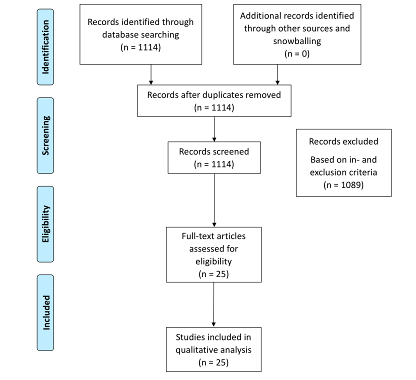

**Figure 1.** PRISMA ﬂowchart showing the yield of the search and inclusion of studies leading to the 25

included studies.

Next to surgically induced OA models, the monosodium iodoacetate (MIA) rat OA model [16,17,23],

the collagenase OA model [13,19] and the spontaneous OA mouse model (STR/Ort) [21] were also used

to investigate chondroprotective actions of selective COX-2 inhibitors celecoxib [13,16,17,19,21] and

after oral administration as evidenced by improved histological scores compared to the controls.

intraperitoneally [25]. In this study, treatment with intraperitoneal etoricoxib injections was started

two days after surgically inducing OA using the destabilization of the medial meniscus (DMM) mouse

model [25] and histological analysis did not demonstrate a reduction in OA-related cartilage damage.

administered selective COX-2 inhibitors since ﬁve studies did not show chondroprotective actions,

while nine studies showed chondroprotective actions after systemic administration with selective

COX-2 inhibitors.

*Int. J. Mol. Sci.* **2020**, *21*, 6962

4 of 15

**Table 1.** The schematic of studies investigating chondroprotective eﬀects of systemically administered selective COX-2 inhibitors.

**Preclinical Studies Using Oral Administration**

**Authors**

**Species**

**COX-2 Inhibitor**

**OA Model**

**Dosing Regime**

**Start of Treatment**

**Timepoint of**

**Evaluation**

**Evaluation of Cartilage**

**Degradation**

**Main Findings**

Mastbergen et al. [12]

Canine

Celecoxib

Groove

Daily 200 mg

Directly after surgery

15 weeks after

OA induction

Histology:Modiﬁed Mankin

Biochemistry: PG content,

synthesis and release

No diﬀerence in histological

scores, no diﬀerence in PG

content, synthesis or release

Huh et al. [13]

Rabbit

Celecoxib

Collagenase

Daily 100 mg/kg

Directly after

OA induction

4 weeks after

OA induction

Histology: Colombo score for

cartilage and synovitis score

for synoviummRNA analysis

*PTGS1, PTGS2*, *MMP1*

and *MMP3*

Improved histological score

in celecoxib group vs.

control, decreased MMP-1

mRNA expression in

celecoxib group vs. control

Jones et al. [22]

Rat

Meloxicam

MCLT + ACLT

+ MMx

Daily 3 mg/kg

Directly after

OA induction

8 weeks after

OA induction

Histology:Modiﬁed Mankin

No diﬀerence in histological

score meloxicam vs. control

Fukai et al. [14]

Mouse

Celecoxib

MCLT + MMx

Daily 10 mg/kg

or 30 mg/ kg

Directly after surgery

12 weeks after

OA induction

Histology:Pritzker score

No diﬀerence in Pritzker

score celecoxib vs. control.

Ou et al. [15]

Rat

Celecoxib

Achilles tendon

transection

Daily 24 mg/kg

Directly after surgery

Histology:Type II collagen

Tunel staining

No diﬀerence in type II

collagen content in celecoxib

vs. control, decreased

chondrocyte apoptosis in

celecoxib group.

Ashkavand et al. [16]

Rat

Celecoxib

MIA

Daily 100 mg/kg

Directly after

OA induction

15 days after

OA induction

Histology: Own

developed score

Improved histological score

in the celecoxib group.

Superior chondroprotective

eﬀects when celecoxib is

combined with silymarin

Moon et al. [17]

Rat

Celecoxib

MIA

Daily 2.5 mg/kg

Directly after

OA induction

7 days after

OA induction

Histology:Modiﬁed Mankin

No diﬀerence in Modiﬁed

Mankin celecoxib vs. control.

Synergistic beneﬁcial action

when celecoxib is

added to rebamipide

Panahifar et al. [18]

Rat

Celecoxib

ACLT + MCLT

+ MMx

Daily

2.86 mg/kg

Directly after surgery

4,8 and 12 weeks after

OA induction

Histology: Modiﬁed Mankin

No diﬀerence in histological

score celecoxib vs. control.

Li [19]

Rat

Celecoxib

Collagenase

Daily 0.25 mg

6 weeks after surgery

10 weeks after

OA induction

Histology: Colombo score and

Biochemistry:CTX-II content in

serum, Caspase 3 activity in

tissue homogenate

Improved histological score

in celecoxib group vs.

control, higher CTX-II

content in celecoxib group,

lower Caspase 3 activity in

celecoxib group.

More pronounced eﬀects

when celecoxib is combined

with diacerein

*Int. J. Mol. Sci.* **2020**, *21*, 6962

5 of 15

**Table 1.** *Cont.*

**Preclinical Studies Using Oral Administration**

**Authors**

**Species**

**COX-2 Inhibitor**

**OA Model**

**Dosing Regime**

**Start of Treatment**

**Timepoint of**

**Evaluation**

**Evaluation of Cartilage**

**Degradation**

**Main Findings**

Dai [20]

Pig

Celecoxib

MMx

20 mg/kg daily

1 week after surgery

12 weeks after surgery

Macroscopic:|OARSI

scoreHistology:OARSI

scoreCOL-II and AGC

immunohistochemistry

Improved macroscopic and

histological score celecoxib

group vs. control,

no diﬀerence in COL-II and

AGC expression

Nagy [23]

Rat

Meloxicam

MIA

Daily 0.2 mg/kg

or 1 mg/kg

3 weeks after

OA induction

11 weeks after

OA induction

Histology: OARSI score

Improved histological score

at both doses meloxicam

compared to control

Tu [21]

Mouse

Celecoxib

Spontaneous OA

(STR/Ort mouse)

Daily 8 mg/kg

3 months old mice

4 weeks after

start treatment

Histology: OARSI score

Improved OARSI score in

celecoxib group vs. controls,

Wen [24]

Rat

Etoricoxib

ACLT

6.7 mg/kg or

33.3 mg/kg three

times per week

8 weeks after surgery

21 weeks after surgery

Histology: Pritzker score

for cartilage

Improved histological score

in the etoricoxib group

versus control

**Preclinical Studies Using Intra-Peritoneal Injections**

Liu [25]

Mouse

Etoricoxib

DMM

5 mg/kg,

10 mg/kg,

20 mg/kg three

times per week

2 days after

OA induction

30 days after surgery

Histology: OARSI score

No diﬀerence in histological

score etoricoxib

versus control.

ACLT: Anterior Cruciate Ligament Transection, CLX: celecoxib, DMM: destabilization medial meniscus, ETX: etoricoxib, MCLT: Medial Collateral Ligament Transection, MIAl: Monosodium

Iodoacetate, MMx: medial meniscectomy, NP: nanoparticle, pMMx: partial medial meniscectomy, PG: proteoglycan.

*Int. J. Mol. Sci.* **2020**, *21*, 6962

6 of 15

*2.2. Preclinical Studies: Intra-Articular Administration*

Next to in vivo studies investigating chondroprotective actions of selective COX-2 inhibitors

administered orally, seven studies focused on their chondroprotective actions when used intra-articularly

(Table 2). These studies evaluated several selective COX-2 inhibitors such as celecoxib [26–29],

parecoxib [30], meloxicam [31] and etoricoxib [32]. All studies used surgically induced OA models.

Chondroprotective actions, as evidenced by improved histological scores, were shown in three studies

after intra-articular administration with selective COX-2 inhibitors [26,30,31]. Four studies investigated

chondroprotective actions of selective COX-2 inhibitors when incorporated in a drug delivery system

(DDS). Dong et al. used celecoxib-loaded liposomes or liposomes loaded with a combination of

liposomes, while liposomes loaded with both celecoxib and hyaluronic acid exerted a chondroprotective

eﬀect compared to control injections [27].

In an earlier study [28], our group has investigated chondroprotective eﬀects of celecoxib-loaded

polyesteramide (PEA) microspheres in a surgically induced rat OA model. While celecoxib-loaded

microspheres reduced PGE2 as measured in homogenates from knees in this experiment, we could

not ﬁnd chondroprotective eﬀects of celecoxib-loaded PEA microspheres as measured by the OARSI

score [28]. In another study, Tellegen et al. [29] evaluated eﬀects of the aforementioned celecoxib-loaded

PEA microspheres on cartilage degeneration in a surgically induced rat OA model. Consistent with our

study, no chondroprotective action of celecoxib-loaded PEA microspheres was observed. In contrast to

the ﬁndings of the aforementioned two studies, one study investigating controlled release of etoricoxib

demonstrated chondroprotective actions as evidenced by improved histological scores compared to

controls [32].

In conclusion, when used intra-articularly, three studies report chondroprotective actions of

selective COX-2 inhibitors. On the other hand, there is conﬂicting evidence regarding chondroprotective

actions of selective COX-2 inhibitors incorporated in intra-articular drug delivery systems: two studies

failed to demonstrate chondroprotective actions, one study shows chondroprotective actions only

when celecoxib is combined with HA and one study demonstrated chondroprotective activity.

*Int. J. Mol. Sci.* **2020**, *21*, 6962

7 of 15

**Table 2.** The schematic of studies investigating chondroprotective eﬀects of intra-articularly administered selective COX-2 inhibitors.

**Preclinical Studies Using Intra-Articular Injections**

**Authors**

**Species**

**COX-2 Inhibitor**

**OA Model**

**Dosing Regime**

**Start of Treatment**

**Timepoint of Evaluation**

**Evaluation of Cartilage Damage**

**Main Findings**

Jean et al. [30]

Rat

Parecoxib

ACLT

Weekly 100 µg

parecoxib for

5 consecutive weeks

Eight weeks

after surgery

20 weeks after surgery

Histology: Mankin score

Improved histological scores

in the parecoxib group

compared to controls

Jiang et al. [26]

Rabbit

Celecoxib

ACLT+ PCLT

+ MMx

Weekly 1.2 mg

celecoxib for

5 consecutive weeks

Directly

after surgery

12 weeks after surgery

Histology: Mankin score

Improved histological scores

in the Celecoxib group

compared to controls

Dong et al. [27]

Celecoxib

ACLT+ PCLT+

MCLT + MMx

Single injection:

0.15 mg celecoxib

incorporated in DDS

One week

after surgery

2 weeks after surgery

Histology: Colombo score

Improved histological score

only when celecoxib is

combined with HA in a DDS

compared to controls

Wen et al. [31]

Rat

Meloxicam

ACLT

Weekly 0.25 or 1 mg

meloxicam for

5 consecutive weeks

Five weeks

after surgery

20 weeks after surgery

Histology: Pritzker score

Lower Pritzker score in the

meloxicam group

versus control

Janssen et al. [28]

Rat

Celecoxib

ACLT + pMMx

Single injection:

0.015 mg celecoxib

incorporated in DDS

Four weeks

after surgery

16 weeks after surgery

Histology: OARSI score

No diﬀerence in histological

score in celecoxib loaded

microspheres vs. control

Tellegen et al. [29]

Rat

Celecoxib

ACLT + pMMx

Single injection: 0.015,

0.115 or 0.195 mg

celecoxib

incorporated in DDS

Four weeks

after surgery

16 weeks after surgery

Histology: OARSI score

No diﬀerence in histological

score in celecoxib loaded

microspheres vs. control

Liu et al. [32]

Rat

Etoricoxib

ACLT

Three injections:

- 10 µM etoricoxib in

100 µL NaCl- 6.93 µg

ETX-NPs, drug

loading unclear

Three, six and nine

weeks after surgery

12 weeks after surgery

Histology: OARSI score

Immunohistochemistry

Improved histological score

in ETX-NP, but not ETX,

compared to control.

ACLT: Anterior Cruciate Ligament Transection, CLX: celecoxib, DDS: drug delivery system, ETX: etoricoxib, HA: hyaluronic acid, MCLT: Medial Collateral Ligament Transection,

MMS: modiﬁed mankin score, MMx: medial meniscectomy, NP: nanoparticle, pMMx: partial medial meniscectomy.

*Int. J. Mol. Sci.* **2020**, *21*, 6962

8 of 15

*2.3. Clinical Studies*

Four clinical studies investigated chondroprotective actions of selective COX-2 inhibitors via oral

administration, while there were no studies investigating chondroprotective actions of selective COX-2

inhibitors after intra-articular administration (Table 3).

Tindall et al. [33] included patients diagnosed with knee OA in a prospective open-label trial.

Patients with OA received celecoxib orally at two dosages throughout a 12-month study period.

Long-term celecoxib treatment did not result in signiﬁcant changes of joint space width (JSW) at 1 year

after treatment as assessed radiographically. Moreover, when radiographic knee OA progression

during the study was compared to radiographic knee OA progression prior to the start of the study,

no signiﬁcant diﬀerences were detected [33].

Sawitzke et al. [34] conducted a placebo-controlled study of patients with knee OA in which

patients received placebo or celecoxib orally on a daily basis. No signiﬁcant diﬀerences were found in

JSW loss compared to placebo at 24 months, while Kellgren and Lawrence grade 2 knees showed a

trend towards less JSW loss. In contrast to the ﬁndings of the aforementioned clinical studies, a study

performed by de Boer et al. suggested that celecoxib might exert chondroprotective actions [35]. In this

study, patients with end-stage knee OA were treated with orally supplemented celecoxib 28 days

prior to total knee replacement surgery. Compared to patients that did not receive celecoxib, cartilage

samples of patients that received celecoxib showed increased proteoglycan (PG) synthesis, decreased

PG release and an increased PG content.

Raynould et al. conducted a study in which patients with knee OA were enrolled receiving

celecoxib orally throughout a 12-month study period [36]. After correcting for potential confounders,

celecoxib treatment did not show any protective eﬀect on cartilage volume loss compared to a historical

knee OA cohort loss, as assessed by quantitative MRI.

In conclusion, evidence of chondroprotective actions of selective COX-2 inhibitors in human

patients is low, since three human in vivo studies failed to show chondroprotective eﬀects of orally

administered celecoxib, while only one study suggests that celecoxib may act chondroprotective

in humans.

The selectivity of the COX-2 inhibitors that were used in the preclinical and clinical studies

described in this review has been compared by Riendeau et al. [37]. The COX-2 selectivity may play

a role in the chondroprotective outcome of a selective COX-2 inhibitor, but the number of studies

described in this systematic review was too small to draw any conclusions. An overview of the

half maximal inhibitory concentration (IC50) values for COX-1 and COX-2 of these selective COX-2

inhibitors together with the COX-1/COX-2 IC50 ratio is provided in Table 4.

*Int. J. Mol. Sci.* **2020**, *21*, 6962

9 of 15

**Table 3.** The schematic overview of clinical studies investigating chondroprotective eﬀects of systemically administered selective COX-2 inhibitors.

**Clinical Studies Using Oral Administration**

**Authors**

**Species**

**COX-2 Inhibitor**

**OA Grade**

**Dosing Regime**

**Treatment Duration**

**Evaluation of Cartilage Damage**

**Chondroprotection**

Tindall et al. [33]

Human

Celecoxib

K&L 2 and 3

Daily 200 or 400 mg

12 months

Radiographs of the knee

No diﬀerence in JSW, subchondral

sclerosis, cysts, malalignment or

tilting after 12 months of treatment

with celecoxib

Sawitzke et al. [34]

Human

Celecoxib

K&L 2 and 3

Daily 200 mg

24 months

Radiographs of the knee

No signiﬁcant diﬀerences in JSW loss

in celecoxib vs. controls

De Boer et al. [35]

Human

Celecoxib

Not speciﬁed

Daily 200 mg

4 weeks

Biochemical cartilage analysis:PG

synthesis rate, PG release

and PG content

Increased PG synthesis rate,

decreased PG release and increased

PG content in the celecoxib group vs.

controls. Decreased release of il-1,

TNF-α and mmp-activity in celecoxib

group vs. control

Raynauld et al. [36]

Human

Celecoxib

K&L 2 and 3

Daily 200 mg

12 months

Quantitative MRI

No diﬀerence in cartilage volume loss

in celecoxib group vs. a historical

cohort control group

JSW: Joint space width, K&L: Kellgren and Lawrence, PG: proteoglycan.

*Int. J. Mol. Sci.* **2020**, *21*, 6962

10 of 15

**Table 4.** The schematic overview of the half maximal inhibitory concentration (IC50) values and the

COX-1/COX-2 IC50 ratio of various selective COX-2 inhibitors. Adapted from [37].

**Drug**

**IC50 COX-1 (****µ****M)**

**IC50 COX-2 (****µ****M)**

**COX-1**/**COX-2 IC****50** **Ratio**

Meloxicam

1.4

0.7

2

Celecoxib

6.7

0.87

7.7

Etoricoxib

116

1.1

105

Parecoxib

26.1

0.87

30

**3. Discussion**

route may be promising, since studies using bolus intra-articular administration of selective COX-2

inhibitors show chondroprotective eﬀects. On the other hand, conﬂicting evidence exists when selective

COX-2 inhibitors are incorporated into a drug delivery system. While preclinical studies point out

to a potential chondroprotective role of COX-2 inhibitors, clinical studies did not investigate the

intra-articular administration route and failed to conﬁrm chondroprotective actions of systemically

administered selective COX-2 inhibitors.

administration failed to demonstrate chondroprotective actions of selective COX-2 inhibitors, all studies

that applied intra-articular bolus injections demonstrated chondroprotective actions. Interestingly,

all clinical studies included in this systematic review evaluated chondroprotective actions using

the systemic administration route.

Since these studies failed to demonstrate chondroprotective

actions, it will be of interest to investigate the chondroprotective actions of selective COX-2 inhibitors

using the intra-articular administration route for clinical studies. We did not encounter studies

comparing chondroprotective eﬀects of systemic versus intra-articularly administration of selective

COX-2 inhibitors, but we believe this will be of interest to investigate in the future.

Improved chondroprotection of intra-articular injections with selective COX-2 inhibitor compared

to a saline control condition may be related to increased bioavailability of the drug in the knee joint

compared to systemic administrations. In addition, in a total joint disease such as knee OA [38–41],

intra-articular administration of drugs may be more eﬀective compared to systemic treatment due to

the presence of scarcely vascularized tissues such as cartilage and meniscus [8]. Since COX-2 inhibitors

can have an eﬀect on all joint tissues, it is unclear whether the chondroprotective eﬀect is a direct result

of COX-2 inhibition in chondrocytes or an eﬀect of COX-2 inhibition of other joint tissues.

Others and we failed to show a reduction of OA-related cartilage damage by celecoxib,

when incorporated in an intra-articular drug delivery system [28,29]. It is a possibility that prolonged

release of celecoxib may counteract potential chondroprotective eﬀects due to increased loading of the

aﬀected joint indirectly caused by the analgesic eﬀects of COX-2 inhibitors. These ﬁndings corroborate

earlier observations in clinical studies, in which patients treated with anti-NGF demonstrated an

increase in OA-related cartilage damage possibly due to joint overloading [5].

COX-2 inhibitors are expected to have anti-inﬂammatory eﬀects by inhibiting the synthesis of

prostanoids. Prostanoid subtypes are considered as inﬂammatory mediators [2] and are involved in

cartilage degradation [3], but also in other pathophysiologic OA processes in diﬀerent joint tissues such

as synovial ﬁbrosis and chondrocyte hypertrophy [42,43]. However, also anti-inﬂammatory actions of

certain prostanoid subtypes have been shown [2], and therefore identifying downstream targets of the

COX-2 pathway may further aid in anti-inﬂammatory treatment for knee OA. Inﬂammatory processes

have been suggested to precede knee OA [4,44] and to be involved in structural disease progression [4].

A window of opportunity may exist, in which modulating the inﬂammatory status of the knee joint

via intra-articular treatment with selective COX-2 inhibitors may lead to OA disease modiﬁcation.

The initiation of treatment may thus be important for the treatment outcome. The studies performed

*Int. J. Mol. Sci.* **2020**, *21*, 6962

11 of 15

by Wen et al. [24] and Dai et al. [20] did not start treatment shortly after surgery and demonstrated

chondroprotective actions of orally administered COX-2 inhibitors. It can be hypothesized that

inhibiting inﬂammation directly after inducing a joint trauma may compromise cartilage regeneration,

since inﬂammation is part of the early phases of natural tissue regeneration after a trauma [45].

This may explain why studies in surgical OA models fail to show chondroprotective eﬀects when

starting treatment directly after surgery. Moreover, the lack of a chondroprotective eﬀect in clinical

studies may be related to the stage of disease. Patients with knee OA are diagnosed in a stadium

when the disease has progressed towards its end-stage [46], and it can be hypothesized that at

this stage the disease is in an irreversible stadium where drug-based disease modiﬁcation is not

eﬀective anymore. In addition, knee OA is a heterogeneous disease showing variability in the rate

Finally, the outcome measurements of clinical studies, such as joint space narrowing on conventional

radiography, may not be sensitive enough. With the ongoing advancements in cartilage imaging [49],

advanced techniques such as 7-tesla MRI imaging [49] may provide a more sensitive means to evaluate

multiple outcome domains relevant to the clinical and pathophysiological aspects of disease modifying

osteoarthritis drug (DMOAD)-mediated disease modiﬁcation.

**4. Materials and Methods**

*4.1. Search Strategy and Data Extraction*

MEDLINE and EMBASE databases were systematically searched on all studies relating

intra-articular or oral treatment of knee OA patients with selective COX-2 inhibitors. The search was

conducted in May 2020 according to the search strategy and data collection guidelines of the preferred

reporting items for systematic reviews and meta-analyses (PRISMA) statement. A manual search of

the Cochrane library yielded no relevant articles. Upon reading the full-text key papers snowballing

searching manually reference lists of the included articles was allowed. Disagreements between the

reviewers were resolved by consensus.

After disregarding duplicates, the title and the abstract of articles were independently screened

by two observers according to predeﬁned criteria. The search query was as follows:

(“Osteoarthritis”[Mesh] OR OA OR osteoarthritis) AND (“Knee”[Mesh] OR Knee [tiab]) AND

(((COX-2 [tiab] OR COX2 [tiab] OR Cyclooxygenase 2 [tiab] OR”Cyclooxygenase 2”[Mesh]) AND

(inhibitor [tiab] or inhibition [tiab] or limitation [tiab] or limiting [tiab])) OR celecoxib [tiab] OR

etoricoxib [tiab] OR rofecoxib [tiab] or valdecoxib [tiab] or lumiracoxib [tiab] or mavacoxib [tiab] or

meloxicam [tiab] or VA441 [tiab] or MK-0966 [tiab] or gw406381 [tiab] or SC-58635 [tiab] or VA692

[tiab] or VA694 [tiab] or SC-236 [tiab]) AND ((oral [tiab] AND (suppletion [tiab] OR supplements [tiab]

OR supplementation [tiab] OR treatment [tiab] OR ingestion [tiab] OR medication [tiab] OR tablets

[tiab] OR intake [tiab] OR absorption [tiab])) OR treatment OR ((intraarticular [tiab] OR intra-articular

[tiab]) AND (injection [tiab] OR therapy [tiab] OR supplementation [tiab] OR suppletion [tiab]))).

*4.2. Articles Were Selected Based on Inclusion and Exclusion Criteria*

Inclusion criteria:

i.

Presenting data about chondroprotective eﬀects of COX-2 inhibitors; The chondroprotective

eﬀect is deﬁned as any eﬀect that leads to signiﬁcantly less cartilage degradation evidenced

either through imaging, biochemical analysis or on histology.

ii.

Either in vivo animal studies or clinical studies involving human knee OA patients;

iii.

Intra-articular therapies with COX-2 inhibitors;

iv.

Systemic therapies with COX-2 inhibitors.

*Int. J. Mol. Sci.* **2020**, *21*, 6962

12 of 15

Exclusion criteria:

i.

Studies solely investigating non-selective cox-inhibitors;

ii.

Studies investigating actions of celecoxib inhibitors on pain modulation in knee OA;

iii.

Studies investigating other joints than the knee;

iv.

Studies reporting solely in vitro data.

Two observers systematically extracted study data based on the inclusion and exclusion criteria.

The risk of bias of the included studies was evaluated using the SYRCLE’s risk of bias tool for animal

studies [10] and the Cochrane risk of bias tool [11] for human studies.

**5. Conclusions**

To date there is conﬂicting evidence regarding the ability of selective COX-2 inhibitors to be used

as DMOADs. Preclinical studies have used diﬀerent routes of administration, which may alter the

chondroprotective outcome of selective COX-2 inhibitors in the knee joint where scarcely vascularized

tissues are present. Other factors such as the OA model type, type of selective COX-2 inhibitor

and disease stage seem also to be involved in the chondroprotective outcome of selective COX-2

inhibitors. Despite the limited evidence of data in clinical studies, there seems to be a preclinical basis

for considering selective COX-2 inhibitors as DMOADs speciﬁcally when used intra-articularly.

**6. Patents**

TJM Welting is listed as inventor on patents: WO2017178251, WO2017178253 and US 20130123314. PJ

Emans and LW van Rhijn are listed as inventors on patent US 20130123314. LW van Rhijn, PJ Emans and

TJM Welting have shares in Chondropeptix and are CDO, CMO and CSO of Chondropeptix, respectively.

**Supplementary Materials:** Supplementary materials can be found at http://www.mdpi.com/1422-0067/21/18/6962/s1.

**Author Contributions:** Conceptualization, U.T.T., M.M.J.C., R.M.J., Y.M.B.-J., T.J.M.W., G.J.V.M.v.O., L.W.v.R.

and P.J.E.; methodology U.T.T., M.M.J.C., R.M.J., T.J.M.W., G.J.V.M.v.O. and P.J.E.; formal analysis, U.T.T., R.M.J.,

M.M.J.C., T.J.M.W., G.J.V.M.v.O. and P.J.E.; writing—original draft preparation, U.T.T.; writing—review and editing

U.T.T., M.M.J.C., R.M.J., Y.M.B.-J., L.W.v.R., T.J.M.W., G.J.V.M.v.O. and P.J.E. All authors have read and agreed to

the published version of the manuscript.

**Funding:** This research was funded by the Dutch Arthritis Foundation (LLP11 and LLP14), the academic fund of

Maastricht University Medical Center and the Annadal Foundation.

**Conﬂicts of Interest:** The authors declare no conﬂict of interest. The funders had no role in the design of the

study; in the collection, analyses, or interpretation of data; in the writing of the manuscript, or in the decision to

publish the results.

**Abbreviations**

ACLT

Anterior cruciate ligament transection

CLX

Celecoxib

COX

Cyclooxygenase

DDS

Drug Delivery System

DMM

Destabilization of the medial meniscus

DMOAD

Disease modifying osteoarthritis drugs

ETX

Etoricoxib

HA

Hyaluronic acid

JSW

Joint space width

K&L

Kellgren and Lawrence

MCLT

Medial collateral ligament transection

MIA

Monosodiumiodoacetate

MMx

Medial meniscus transection

MRI

Magnetic Resonance Imaging

NP

Nanoparticle

NSAID

Non-steroidal anti-inﬂammatory drugs

*Int. J. Mol. Sci.* **2020**, *21*, 6962

13 of 15

OA

Osteoarthritis

PEA

Polyesteramide

Pg

Prostaglandin

PG

Proteoglycan

pMMx

Partial medial meniscus transection

**References**

1.

Hunter, D.J.; Felson, D.T. Osteoarthritis. *BMJ* **2006**, *332*, 639–642. [CrossRef]

2.

Ricciotti, E.; FitzGerald, G.A. Prostaglandins and inflammation. *Arterioscler Thromb Vasc. Biol.* **2011**, *31*, 986–1000.

[CrossRef]

3.

Martel-Pelletier, J.; Pelletier, J.P.; Fahmi, H. Cyclooxygenase-2 and prostaglandins in articular tissues.

*Semin. Arthritis Rheum.* **2003**, *33*, 155–167. [CrossRef]

4.

Ayral, X.; Pickering, E.H.; Woodworth, T.G.; Mackillop, N.; Dougados, M. Synovitis: A potential predictive

factor of structural progression of medial tibiofemoral knee osteoarthritis—Results of a 1 year longitudinal

arthroscopic study in 422 patients. *Osteoarthritis Cartilage* **2005**, *13*, 361–367. [CrossRef]

5.

Miller, R.E.; Block, J.A.; Malfait, A.M. Nerve growth factor blockade for the management of osteoarthritis

pain: What can we learn from clinical trials and preclinical models? *Curr. Opin. Rheumatol.* **2017**, *29*, 110–118.

[CrossRef]

6.

Ding, C. Do NSAIDs aﬀect the progression of osteoarthritis? *Inﬂammation* **2002**, *26*, 139–142. [CrossRef]

7.

Zweers, M.C.; De Boer, T.N.; Van Roon, J.; Bijlsma, J.W.; Lafeber, F.P.; Mastbergen, S.C. Celecoxib:

Considerations regarding its potential disease-modifying properties in osteoarthritis. *Arthritis Res. Ther.*

**2011**, *13*, 239. [CrossRef]

8.

Buckwalter, J.A.; Mankin, H.J. Articular cartilage: Tissue design and chondrocyte-matrix interactions.

*Instr. Course Lect.* **1998**, *47*, 477–486.

9.

Makris, E.A.; Hadidi, P.; Athanasiou, K.A. The knee meniscus: Structure-function, pathophysiology, current

repair techniques, and prospects for regeneration. *Biomaterials* **2011**, *32*, 7411–7431. [CrossRef]

10.

Hooijmans, C.R.; Rovers, M.M.; De Vries, R.B.; Leenaars, M.; Ritskes-Hoitinga, M.; Langendam, M.W.

SYRCLE’s risk of bias tool for animal studies. *BMC Med. Res. Methodol* **2014**, *14*, 43. [CrossRef]

11.

Van der Kraan, P.M.; Buma, P.; Van Kuppevelt, T.; Van den Berg, W.B. Interaction of chondrocytes, extracellular

matrix and growth factors: Relevance for articular cartilage tissue engineering. *Osteoarthritis Cartilage* **2002**,

*10*, 631–637. [CrossRef]

12.

Mastbergen, S.C.; Marijnissen, A.C.; Vianen, M.E.; Zoer, B.; Van Roermund, P.M.; Bijlsma, J.W.; Lafeber, F.P.

Inhibition of COX-2 by celecoxib in the canine groove model of osteoarthritis. *Rheumatology* **2006**, *45*, 405–413.

[CrossRef]

13.

Huh, J.E.; Baek, Y.H.; Kim, Y.J.; Lee, J.D.; Choi, D.Y.; Park, D.S. Protective eﬀects of butanol fraction from

Betula platyphyla var. japonica on cartilage alterations in a rabbit collagenase-induced osteoarthritis.

*J. Ethnopharmacol* **2009**, *123*, 515–521. [CrossRef]

14.

Fukai, A.; Kamekura, S.; Chikazu, D.; Nakagawa, T.; Hirata, M.; Saito, T.; Hosaka, Y.; Ikeda, T.; Nakamura, K.;

Chung, U.; et al. Lack of a chondroprotective eﬀect of cyclooxygenase 2 inhibition in a surgically induced

model of osteoarthritis in mice. *Arthritis Rheum.* **2012**, *64*, 198–203. [CrossRef]

15.

Ou, Y.; Tan, C.; An, H.; Jiang, D.; Quan, Z.; Tang, K.; Luo, X. Selective COX-2 inhibitor ameliorates

osteoarthritis by repressing apoptosis of chondrocyte. *Med. Sci. Monit.* **2012**, *18*, BR247–BR252. [CrossRef]

16.

Ashkavand, Z.; Malekinejad, H.; Amniattalab, A.; Rezaei-Golmisheh, A.; Vishwanath, B.S. Silymarin

potentiates the anti-inﬂammatory eﬀects of Celecoxib on chemically induced osteoarthritis in rats.

*Phytomedicine* **2012**, *19*, 1200–1205. [CrossRef]

17.

Moon, S.J.; Park, J.S.; Jeong, J.H.; Yang, E.J.; Park, M.K.; Kim, E.K.; Park, S.H.; Kim, H.Y.; Cho, M.L.; Min, J.K.

Augmented chondroprotective eﬀect of coadministration of celecoxib and rebamipide in the monosodium

iodoacetate rat model of osteoarthritis. *Arch. Pharm. Res.* **2013**, *36*, 116–124. [CrossRef]

18.

Panahifar, A.; Jaremko, J.L.; Tessier, A.G.; Lambert, R.G.; Maksymowych, W.P.; Fallone, B.G.; Doschak, M.R.

Development and reliability of a multi-modality scoring system for evaluation of disease progression in

pre-clinical models of osteoarthritis: Celecoxib may possess disease-modifying properties. *Osteoarthritis Cartilage*

**2014**, *22*, 1639–1650. [CrossRef]

*Int. J. Mol. Sci.* **2020**, *21*, 6962

14 of 15

19.

Li, Z.; Meng, D.; Li, G.; Xu, J.; Tian, K.; Li, Y. Celecoxib Combined with Diacerein Effectively Alleviates

Osteoarthritis in Rats via Regulating JNK and p38MAPK Signaling Pathways. *Inflammation* **2015**, *38*, 1563–1572.

[CrossRef]

20.

Dai, M.W.; Chu, J.G.; Tian, F.M.; Song, H.P.; Wang, Y.; Zhang, Y.Z.; Zhang, L. Parathyroid hormone(1-34)

exhibits more comprehensive eﬀects than celecoxib in cartilage metabolism and maintaining subchondral

bone micro-architecture in meniscectomized guinea pigs.

*Osteoarthritis Cartilage* **2016**, *24*, 1103–1112.

[CrossRef]

21.

Tu, M.; Yang, M.; Yu, N.; Zhen, G.; Wan, M.; Liu, W.; Ji, B.; Ma, H.; Guo, Q.; Tong, P.; et al. Inhibition of

cyclooxygenase-2 activity in subchondral bone modiﬁes a subtype of osteoarthritis. *Bone Res.* **2019**, *7*, 29.

[CrossRef]

22.

Jones, M.D.; Tran, C.W.; Li, G.; Maksymowych, W.P.; Zernicke, R.F.; Doschak, M.R. In vivo microfocal

computed tomography and micro-magnetic resonance imaging evaluation of antiresorptive and

antiinﬂammatory drugs as preventive treatments of osteoarthritis in the rat.

*Arthritis Rheum.*

**2010**,

*62*, 2726–2735. [CrossRef]

23.

Nagy, E.; Vajda, E.; Vari, C.; Sipka, S.; Farr, A.M.; Horvath, E. Meloxicam ameliorates the cartilage and

subchondral bone deterioration in monoiodoacetate-induced rat osteoarthritis. *PeerJ* **2017**, *5*, e3185. [CrossRef]

24.

Wen, Z.H.; Lin, Y.Y.; Chang, Y.C.; Tang, C.C.; Hsieh, S.P.; Lee, H.P.; Sung, C.S.; Chen, W.F.; Lee, C.H.; Jean, J.H.

The COX-2 inhibitor etoricoxib reduces experimental osteoarthritis and nociception in rats: The roles of

TGF-beta1 and NGF expressions in chondrocytes. *Eur. J. Pain.* **2020**, *24*, 209–222. [CrossRef] [PubMed]

25.

Liu, B.; Ji, C.; Shao, Y.; Liang, T.; He, J.; Jiang, H.; Chen, G.; Luo, Z. Etoricoxib decreases subchondral

bone mass and attenuates biomechanical properties at the early stage of osteoarthritis in a mouse model.

*Biomed Pharmacother* **2020**, *127*, 110144. [CrossRef]

26.

Jiang, D.; Zou, J.; Huang, L.; Shi, Q.; Zhu, X.; Wang, G.; Yang, H. Eﬃcacy of intra-articular injection of

celecoxib in a rabbit model of osteoarthritis. *Int. J. Mol. Sci.* **2010**, *11*, 4106. [CrossRef]

27.

Dong,J.; Jiang,D.; Wang, Z.; Wu,G.; Miao,L.; Huang, L.Intra-articulardeliveryofliposomalcelecoxib-hyaluronate

combination for the treatment of osteoarthritis in rabbit model. *Int. J. Pharm.* **2013**, *441*, 285–290. [CrossRef]

28.

Janssen, M.; Timur, U.T.; Woike, N.; Welting, T.J.; Draaisma, G.; Gijbels, M.; van Rhijn, L.W.; Mihov, G.;

Thies, J.C.; Emans, P.J. Celecoxib-loaded PEA microspheres as an auto regulatory drug-delivery system after

intra-articular injection. *J. Control Release.* **2016**, *244*, 30–40. [CrossRef]

29.

Tellegen, A.R.; Rudnik-Jansen, I.; Pouran, B.; De Visser, H.M.; Weinans, H.H.; Thomas, R.E.; Kik, M.J.L.;

Grinwis, G.C.M.; Thies, J.C.; Woike, N.; et al. Controlled release of celecoxib inhibits inflammation, bone cysts

and osteophyte formation in a preclinical model of osteoarthritis. *Drug Deliv.* **2018**, *25*, 1438–1447. [CrossRef]

30.

Jean, Y.H.; Wen, Z.H.; Chang, Y.C.; Hsieh, S.P.; Tang, C.C.; Wang, Y.H.; Wong, C.S. Intra-articular injection

of the cyclooxygenase-2 inhibitor parecoxib attenuates osteoarthritis progression in anterior cruciate

ligament-transected knee in rats: Role of excitatory amino acids. *Osteoarthritis Cartilage* **2007**, *15*, 638–645.

[CrossRef]

31.

Wen, Z.H.; Tang, C.C.; Chang, Y.C.; Huang, S.Y.; Chen, C.H.; Wu, S.C.; Hsieh, S.P.; Hsieh, C.S.; Wang, K.Y.;

Lin, S.Y.; et al. Intra-articular injection of the selective cyclooxygenase-2 inhibitor meloxicam (Mobic) reduces

experimental osteoarthritis and nociception in rats. *Osteoarthritis Cartilage* **2013**, *21*, 1976–1986. [CrossRef]

[PubMed]

32.

Liu, P.; Gu, L.; Ren, L.; Chen, J.; Li, T.; Wang, X.; Yang, J.; Chen, C.; Sun, L. Intra-articular injection of

etoricoxib-loaded PLGA-PEG-PLGA triblock copolymeric nanoparticles attenuates osteoarthritis progression.

*Am. J. Transl. Res.* **2019**, *11*, 6775–6789. [PubMed]

33.

Tindall, E.A.; Sharp, J.T.; Burr, A.; Katz, T.K.; Wallemark, C.B.; Verburg, K.; Lefkowith, J. A 12-month,

multicenter, prospective, open-label trial of radiographic analysis of disease progression in osteoarthritis of

the knee or hip in patients receiving celecoxib. *Clin Ther.* **2002**, *24*, 2051–2063. [CrossRef]

34.

Sawitzke, A.D.; Shi, H.; Finco, M.F.; Dunlop, D.D.; 3rd Bingham, C.O.; Harris, C.L.; Singer, N.G.; Bradley, J.D.;

Silver, D.; Jackson, C.G.; et al. The eﬀect of glucosamine and/or chondroitin sulfate on the progression of

knee osteoarthritis: A report from the glucosamine/chondroitin arthritis intervention trial. *Arthritis Rheum.*

**2008**, *58*, 3183–3191. [CrossRef] [PubMed]

*Int. J. Mol. Sci.* **2020**, *21*, 6962

15 of 15

35.

De Boer, T.N.; Huisman, A.M.; Polak, A.A.; Niehoﬀ, A.G.; Van Rinsum, A.C.; Saris, D.; Bijlsma, J.W.J.;

Lafeber, F.J.P.G.; Mastbergen, S.C. The chondroprotective eﬀect of selective COX-2 inhibition in osteoarthritis:

Ex vivo evaluation of human cartilage tissue after in vivo treatment. *Osteoarthritis Cartilage* **2009**, *17*, 482–488.

[CrossRef] [PubMed]

36.

Raynauld, J.P.; Martel-Pelletier, J.; Beaulieu, A.; Bessette, L.; Morin, F.; Choquette, D.; Haraoui, B.; Abram, F.;

Pelletier, J.P. An open-label pilot study evaluating by magnetic resonance imaging the potential for a

disease-modifying eﬀect of celecoxib compared to a modelized historical control cohort in the treatment of

knee osteoarthritis. *Semin. Arthritis Rheum.* **2010**, *40*, 185–192. [CrossRef]

37.

Riendeau, D.; Percival, M.D.; Brideau, C.; Charleson, S.; Dubé, D.; Ethier, D.; Falgueyret, J.P.; Friesen, R.W.;

Gordon, R.; Greig, G.; et al. Etoricoxib (MK-0663): Preclinical Proﬁle and Comparison with other agents that

selectively inhibit Cyclooxygenase-2. *J. Pharmacol. Exp. Ther.* **2001**, *296*, 558–566.

38.

Loeser, R.F.; Goldring, S.R.; Scanzello, C.R.; Goldring, M.B. Osteoarthritis: A disease of the joint as an organ.

*Arthritis Rheum.* **2012**, *64*, 1697–1707. [CrossRef]

39.

Clockaerts, S.; Bastiaansen-Jenniskens, Y.M.; Runhaar, J.; Van Osch, G.J.; Van Oﬀel, J.F.; Verhaar, J.A.;

de Clerck, L.S.; Somville, J. The infrapatellar fat pad should be considered as an active osteoarthritic joint

tissue: A narrative review. *Osteoarthritis Cartilage* **2010**, *18*, 876–882. [CrossRef]

40.

Weinberg, J.B.; Fermor, B.; Guilak, F. Nitric oxide synthase and cyclooxygenase interactions in cartilage and

meniscus: Relationships to joint physiology, arthritis, and tissue repair. *Subcell Biochem.* **2007**, *42*, 31–62.

41.

De Lange-Brokaar, B.J.; Ioan-Facsinay, A.; Van Osch, G.J.; Zuurmond, A.M.; Schoones, J.; Toes, R.E.;

Huizinga, T.W.J.; Kloppenburg, M. Synovial inﬂammation, immune cells and their cytokines in osteoarthritis:

A review. *Osteoarthritis Cartilage* **2012**, *20*, 1484–1499. [CrossRef]

42.

Bastiaansen-Jenniskens, Y.M.; Wei, W.; Feijt, C.; Waarsing, J.H.; Verhaar, J.A.; Zuurmond, A.M.;

Hanemaaijer, R.; Stoop, R.; van Osch, G.J.V.M. Stimulation of ﬁbrotic processes by the infrapatellar fat

pad in cultured synoviocytes from patients with osteoarthritis: A possible role for prostaglandin f2alpha.

*Arthritis Rheum.* **2013**, *65*, 2070–2080. [CrossRef]

43.

Welting, T.J.; Caron, M.M.; Emans, P.J.; Janssen, M.P.; Sanen, K.; Coolsen, M.M.; Voss, L.; Surtel, D.A.;

Cremers, A.; Voncken, J.; et al.

Inhibition of cyclooxygenase-2 impacts chondrocyte hypertrophic

diﬀerentiation during endochondral ossiﬁcation. *Eur. Cell Mater.* **2011**, *22*, 420–437. [CrossRef]

44.

Felson, D.T.; Niu, J.; Neogi, T.; Goggins, J.; Nevitt, M.C.; Roemer, F.; Torner, J.; Lewis, C.E.; Guermazi, A.

Synovitis and the risk of knee osteoarthritis: The MOST Study. *Osteoarthritis Cartilage* **2016**, *24*, 458–464.

[CrossRef]

45.

Karin, M.; Clevers, H. Reparative inﬂammation takes charge of tissue regeneration. *Nature* **2016**, *529*, 307–315.

[CrossRef]

46.

Glyn-Jones, S.; Palmer, A.J.; Agricola, R.; Price, A.J.; Vincent, T.L.; Weinans, H.; Carr, A.J. Osteoarthritis.

*Lancet* **2015**, *386*, 376–387. [CrossRef]

47.

Karsdal, M.A.; Christiansen, C.; Ladel, C.; Henriksen, K.; Kraus, V.B.; Bay-Jensen, A.C. Osteoarthritis–a case

for personalized health care? *Osteoarthritis Cartilage* **2014**, *22*, 7–16. [CrossRef]

48.

Waarsing, J.H.; Bierma-Zeinstra, S.M.; Weinans, H. Distinct subtypes of knee osteoarthritis: Data from the

Osteoarthritis Initiative. *Rheumatology* **2015**, *54*, 1650–1658. [CrossRef]

49.

Oei, E.H.G.; Wick, M.C.; Muller-Lutz, A.; Schleich, C.; Miese, F.R. Cartilage Imaging: Techniques and

Developments. *Semin. Musculoskelet. Radiol.* **2018**, *22*, 245–260. [CrossRef]

[figure not shown]

© 2020 by the authors. Licensee MDPI, Basel, Switzerland. This article is an open access

article distributed under the terms and conditions of the Creative Commons Attribution

(CC BY) license (http://creativecommons.org/licenses/by/4.0/).